# Evolução da bola de três pontos na NBA

Eli Jose, Gabriel Monteiro, Pedro Azambuja

R para Ciência dos Dados

[figure not shown]

Stephen Curry | New York Times

# Sobre o trabalho

A linha de três pontos no basquete surgiu em 1933 como uma alternativa para que jogadores com estaturas menores pudessem competir com jogadores mais altos. O primeiro teste oficial aconteceu na liga universitária americana(NCAA) e só acabou sendo introduzida na NBA na temporada 1979-1980. A sua utilização só se tornou relevante no final dos anos 80 e se consolidou como uma estratégia relevante no jogo nos anos 90, com a ascensão de bons arremessadores como Steve Kerr, Reggie Miller, Mark Price, Dell Curry entre muitos outros. A partir da popularização, o estilo de jogo dos times foi sofrendo mudanças e assim começaram a se formar equipes que focavam suas estratégias ofensivas na bola de 3 pontos, como o Phoenix Suns de Steve Nash e Mike D’Antoni e mais recentemente a dominante equipe do Golden State Warriors com Stephen Curry, Klay Thompson e Kevin Durant.

O objetivo deste projeto é analisar a mudanças de comportamento das equipes da temporada 2003 até 2019 a fim de notar uma participação maior da bola de três pontos no basquete da NBA. O dataset usado é público e pode ser encontrado neste link do [Kaggle](https://www.kaggle.com/nathanlauga/nba-games).

# Dados Utilizados

Os datasets utilizados foram dos arquivos games.csv e games_details.csv. O primeiro possui informações gerais sobre todos jogos ocorridos entre 2003 e 2020, como informações de placares, pontuação do time da casa e visitante assim como a temporada em que o jogo foi realizado. O segundo possui o box score de cada jogo, assim cada linha traz informações relacionadas a estatísticas de quadra de um jogador junto com qual time este joga e em qual jogo aquelas estatísticas são referentes.

No primeiro momento, foi feito um pré processamento dos dados com a intenção de:

- Adicionar a coluna SEASON(referente a temporada em que o jogo foi realizado) a tabela com os detalhes dos jogos.
- Retirar linhas irrelevantes para análises que continham jogadores que não haviam entrado em quadra, logo suas estatísticas eram nulas.
- Criar as colunas de arremessos de dois pontos convertidos, arremessos de dois pontos realizados e porcentagem de acerto de arremessos de dois pontos. Atualmente só existe a coluna de arremessos totais convertidos e tentados assim como de arremessos de três pontos.
- Retirar a temporada 2020 da análise pois devido a pandemia do Covid-19 esta temporada teve menos jogos.

```r
# Import dataset de jogos
games = tibble(read.csv('games.csv'))
head(games)
```

```
## # A tibble: 6 x 21
##   GAME_DATE_EST  GAME_ID GAME_STATUS_TEXT HOME_TEAM_ID VISITOR_TEAM_ID SEASON
##   <chr>            <int> <chr>                   <int>           <int>  <int>
## 1 2021-03-21    22000645 Final              1610612748      1610612754   2020
## 2 2021-03-21    22000016 Final              1610612745      1610612760   2020
## 3 2021-03-21    22000646 Final              1610612743      1610612740   2020
## 4 2021-03-21    22000167 Final              1610612738      1610612753   2020
## 5 2021-03-21    22000647 Final              1610612751      1610612764   2020
## 6 2021-03-21    22000648 Final              1610612739      1610612761   2020
## # … with 15 more variables: TEAM_ID_home <int>, PTS_home <dbl>,
## #   FG_PCT_home <dbl>, FT_PCT_home <dbl>, FG3_PCT_home <dbl>, AST_home <dbl>,
## #   REB_home <dbl>, TEAM_ID_away <int>, PTS_away <dbl>, FG_PCT_away <dbl>,
## #   FT_PCT_away <dbl>, FG3_PCT_away <dbl>, AST_away <dbl>, REB_away <dbl>,
## #   HOME_TEAM_WINS <int>
```

```r
# Import dataset com detalhes dos jogos
games_details = tibble(read.csv('games_details.csv'))
head(games_details)
```

```
## # A tibble: 6 x 28
##    GAME_ID    TEAM_ID TEAM_ABBREVIATION TEAM_CITY PLAYER_ID PLAYER_NAME
##      <int>      <int> <chr>             <chr>         <int> <chr>
## 1 22000645 1610612754 IND               Indiana      203200 Justin Holiday
## 2 22000645 1610612754 IND               Indiana     1627734 Domantas Sabonis
## 3 22000645 1610612754 IND               Indiana     1626167 Myles Turner
## 4 22000645 1610612754 IND               Indiana     1627747 Caris LeVert
## 5 22000645 1610612754 IND               Indiana     1627763 Malcolm Brogdon
## 6 22000645 1610612754 IND               Indiana      203926 Doug McDermott
## # … with 22 more variables: START_POSITION <chr>, COMMENT <chr>, MIN <chr>,
## #   FGM <dbl>, FGA <dbl>, FG_PCT <dbl>, FG3M <dbl>, FG3A <dbl>, FG3_PCT <dbl>,
## #   FTM <dbl>, FTA <dbl>, FT_PCT <dbl>, OREB <dbl>, DREB <dbl>, REB <dbl>,
## #   AST <dbl>, STL <dbl>, BLK <dbl>, TO <dbl>, PF <dbl>, PTS <dbl>,
## #   PLUS_MINUS <dbl>
```

```r
# Removendo NaNs, adicionando coluna das temporadas e criando
# colunas para estatísticas de arremessos de 2 pontos
df <- games_details %>%
  na.omit() %>%
  inner_join(games%>% dplyr::select(GAME_ID, SEASON),
             by="GAME_ID") %>%
  mutate(FG2M = FGM - FG3M,
         FG2A = FGA - FG3A,
         FG2_PCT = FG2M/FG2A) %>%
  filter(SEASON != c('2020'))

head(df)
```

```
## # A tibble: 6 x 32
##    GAME_ID    TEAM_ID TEAM_ABBREVIATI… TEAM_CITY  PLAYER_ID PLAYER_NAME
##      <int>      <int> <chr>            <chr>          <int> <chr>
## 1 41900406 1610612747 LAL              Los Angel…      2544 LeBron James
## 2 41900406 1610612747 LAL              Los Angel…    201980 Danny Green
## 3 41900406 1610612747 LAL              Los Angel…    203076 Anthony Davis
## 4 41900406 1610612747 LAL              Los Angel…   1627936 Alex Caruso
## 5 41900406 1610612747 LAL              Los Angel…    203484 Kentavious Caldwell…
## 6 41900406 1610612747 LAL              Los Angel…    200765 Rajon Rondo
## # … with 26 more variables: START_POSITION <chr>, COMMENT <chr>, MIN <chr>,
## #   FGM <dbl>, FGA <dbl>, FG_PCT <dbl>, FG3M <dbl>, FG3A <dbl>, FG3_PCT <dbl>,
## #   FTM <dbl>, FTA <dbl>, FT_PCT <dbl>, OREB <dbl>, DREB <dbl>, REB <dbl>,
## #   AST <dbl>, STL <dbl>, BLK <dbl>, TO <dbl>, PF <dbl>, PTS <dbl>,
## #   PLUS_MINUS <dbl>, SEASON <int>, FG2M <dbl>, FG2A <dbl>, FG2_PCT <dbl>
```

# Arremessos de três pontos ao longo dos anos

A primeira análise buscou entender se da temporada 2003 até 2019 houve ou não uma mudança de comportamento na estratégia dos times referente a utilização de arremessos de três pontos. Para isso, será utilizado dois gráficos:

1. Arremessos de dois pontos convertidos e realizados
2. Arremessos de três pontos convertidos e realizados

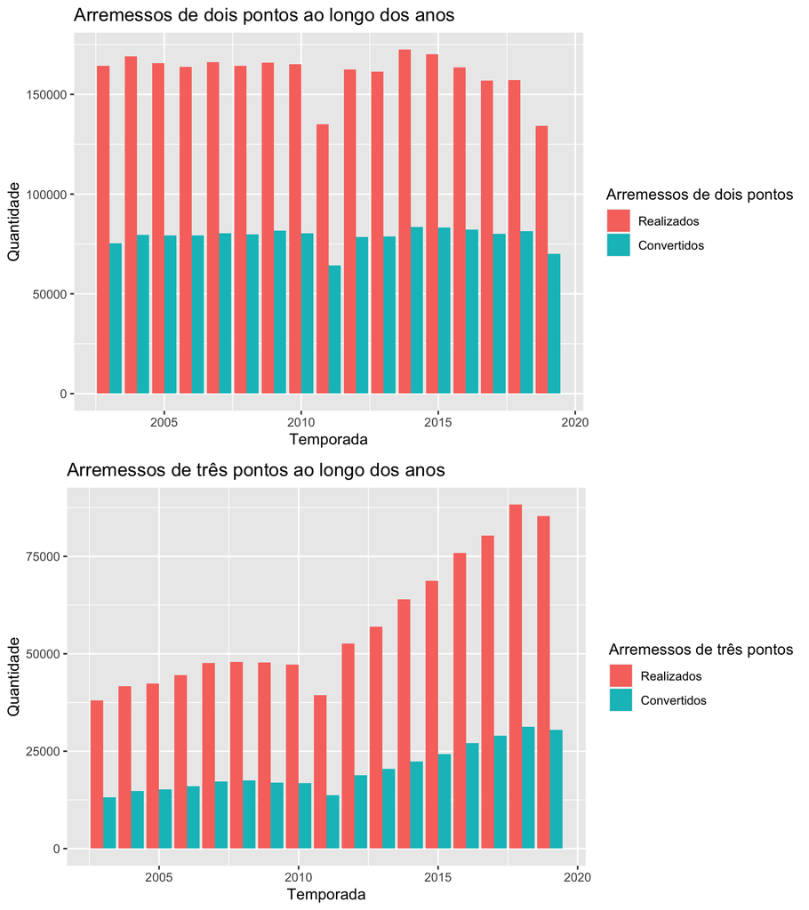

```r
df_1 <- df %>%
  group_by(SEASON) %>%
  summarise(TOTAL_FGM = sum(FGM), TOTAL_FGA = sum(FGA),
            TOTAL_2PTM = sum(FG2M), TOTAL_2PTA = sum(FG2A),
            TOTAL_3PTM = sum(FG3M), TOTAL_3PTA = sum(FG3A)) %>%
  pivot_longer(!SEASON,
               names_to = "FG_TYPE",
               values_to = "count")

two_plot <- ggplot(df_1 %>% filter(FG_TYPE %in% c('TOTAL_2PTM','TOTAL_2PTA')),aes(x = SEASON,y = count)) +
  geom_bar(aes(fill = FG_TYPE),stat = "identity",position = position_dodge()) +
  ggtitle("Arremessos de dois pontos ao longo dos anos") +
  labs(y="Quantidade", x="Temporada") +
  scale_fill_discrete(name = "Arremessos de dois pontos", labels = c("Realizados", "Convertidos"))

three_plot <- ggplot(df_1 %>% filter(FG_TYPE %in% c('TOTAL_3PTM','TOTAL_3PTA')),aes(x = SEASON,y = count)) +
  geom_bar(aes(fill = FG_TYPE),stat = "identity",position = position_dodge()) +
  ggtitle("Arremessos de três pontos ao longo dos anos") +
  labs(y="Quantidade", x="Temporada") +
  scale_fill_discrete(name = "Arremessos de três pontos", labels = c("Realizados", "Convertidos"))

grid.arrange(two_plot, three_plot, ncol = 1)
```

Nos arremessos de dois pontos, tanto convertidos quanto realizados, não se observa uma variação relevante até 2014, depois desse período é possível observar uma queda nos arremessos realizados. Já nos arremessos de três pontos, a partir de 2012 existe uma alta expressiva na tentativa de arremessos acompanhada com uma alta também em arremessos convertidos. Desta forma, é possível inferir que os times vem cada vez mais utilizando o arremesso de três pontos como arma ofensiva, e não somente realizando mais arremessos no geral, como poderia ser o caso se os arremessos de dois pontos também estivessem em crescimento.

# Distribuição de pontos por tipo de arremesso ao longo dos anos

Após notar uma leve queda nas tentativas de arremessos de 2 pontos e uma forte alta na tentativa de arremessos de três pontos, vamos observar a distribuição dos pontos marcados em cada temporada pelo tipo de arremesso convertido. Para isso, somamos os pontos feitos em cada temporada e calculamos a proporção de cada tipo de arremesso desses pontos. Lembrando que no basquete da NBA existem três tipos de arremessos:

1. Lance livre: vale um ponto
2. Arremesso dentro da linha de três pontos: vale dois pontos
3. Arremesso atrás da linha de três pontos: vale três pontos

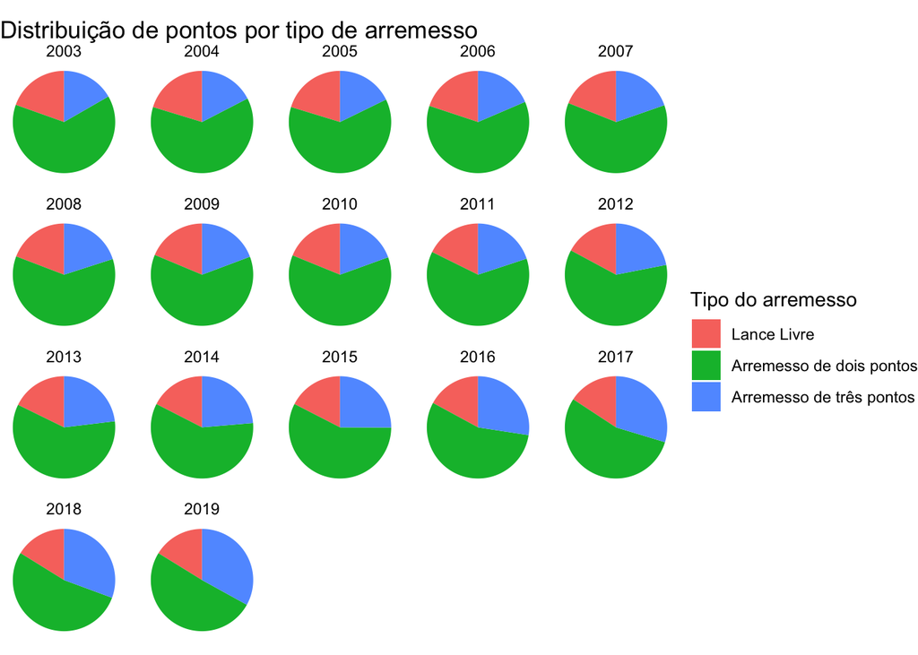

```r
df_2 <- df %>%
  group_by(SEASON) %>%
  summarise(FTs = sum(FTM),PT2s = sum(FG2M*2), PT3s = sum(FG3M*3),TOTAL_PTS = sum(PTS)) %>%
  pivot_longer(!c(SEASON,TOTAL_PTS), names_to = "SHOT_TYPE", values_to = "count") %>%
  mutate(pct = (count/TOTAL_PTS*100))

ggplot(df_2, aes(x="", y=count, fill=SHOT_TYPE)) +
  geom_col(position = "fill")  +
  coord_polar(theta="y") +
  facet_wrap(~ SEASON) +
  theme_void() +
  ggtitle("Distribuição de pontos por tipo de arremesso") +
  scale_fill_discrete(name = "Tipo do arremesso", labels = c("Lance Livre", "Arremesso de dois pontos","Arremesso de três pontos"))
```

Observando os anos de 2003 até 2012, é possível notar que os pontos originados de lances livres e arremessos de três pontos possuem proporções parecidas, enquanto os originados de dois pontos são dominantes. A partir de 2013 é visualmente notável que os pontos originados de arremessos de três pontos começam a tomar uma proporção maior, enquanto os pontos de lances livres acabam se mantendo. Os pontos de arremessos dois pontos mesmo dominantes, cedem espaços para os pontos originados dos arremessos de três pontos.

# Distruibuição dos arremessos de dois e três pontos por posição

Com as duas análises anteriores, está claro que os arremessos de três pontos não só são cada vez mais frequentes como possuem uma participação maior nos pontos anotados pelas equipes. Dessa forma, a próxima análise busca observar essas mudanças no comportamento dos jogadores, focando nas posições deles em quadra. Assim, foram montados dois gráficos que mostram a participação de cada posição nos arremessos de dois e três pontos feitos durante os anos.

```r
df_3 <- df %>%
  group_by(SEASON, START_POSITION) %>%
  filter(!START_POSITION == "") %>%
  summarise(TOTAL_2PTM = sum(FG2M), TOTAL_2PTA = sum(FG2A),
            TOTAL_3PTM = sum(FG3M), TOTAL_3PTA = sum(FG3A)) %>%
  mutate(pct_2PTM = TOTAL_2PTM/sum(TOTAL_2PTM),pct_2PTA = TOTAL_2PTA/sum(TOTAL_2PTA),
         pct_3PTM = TOTAL_3PTM/sum(TOTAL_3PTM),pct_3PTA = TOTAL_3PTA/sum(TOTAL_3PTA))
```

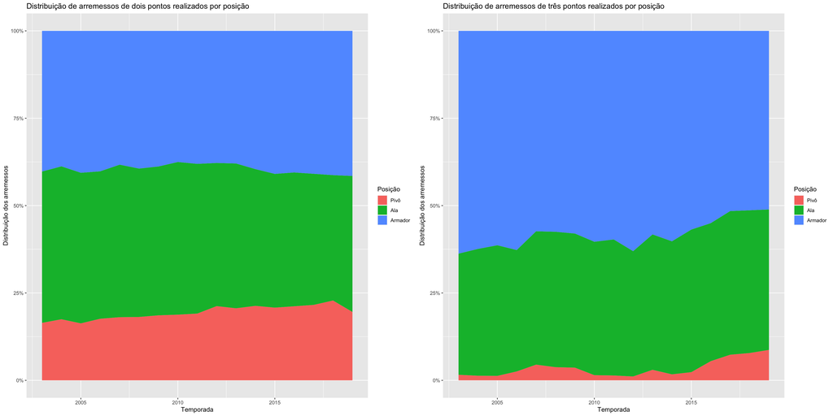

```r
two_pos_plot <- ggplot(df_3,aes(x = SEASON,y = pct_2PTA)) +
  geom_area(aes(fill = START_POSITION),stat = "identity",position = position_fill(reverse = TRUE)) +
  scale_y_continuous(labels = scales::percent) +
  ggtitle("Distribuição de arremessos de dois pontos realizados por posição") +
  labs(y="Distribuição dos arremessos", x="Temporada") +
  scale_fill_discrete(name = "Posição", labels = c("Pivô", "Ala", "Armador"))

three_pos_plot <- ggplot(df_3,aes(x = SEASON,y = pct_3PTA)) +
  geom_area(aes(fill = START_POSITION),stat = "identity",position = position_fill(reverse = TRUE)) +
  scale_y_continuous(labels = scales::percent) +
  ggtitle("Distribuição de arremessos de três pontos realizados por posição") +
  labs(y="Distribuição dos arremessos", x="Temporada") +
  scale_fill_discrete(name = "Posição", labels = c("Pivô", "Ala", "Armador"))

grid.arrange(two_pos_plot, three_pos_plot, ncol = 2)
```

A porcentagem de arremessos de dois pontos por posição não variou de forma significativa, enquanto os arremessos de três pontos tiveram uma participação maior dos pivôs e dos alas a partir de 2015. Agora vamos observar a efetividade do arremesso de três pontos por posição ao longo dos anos e ver se além de arremessar mais, os alas e os pivôs também aperfeiçoaram o arremesso.

# Aproveitamento do arremesso de três pontos por posição

```r
df_4 <- df %>%
  group_by(SEASON, START_POSITION) %>%
  filter(!START_POSITION == "") %>%
  summarise(PT3_RATE = mean(FG3_PCT))
```

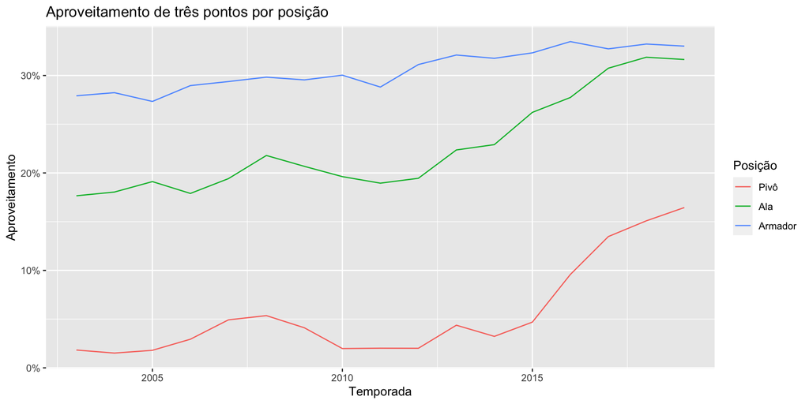

```r
ggplot(df_4,aes(x = SEASON,y = PT3_RATE, group=START_POSITION, color=START_POSITION)) +
  geom_line() +
  ggtitle("Aproveitamento de três pontos por posição") +
  labs(y="Aproveitamento", x="Temporada", color="Posição") +
  scale_color_discrete(labels = c("Pivô", "Ala", "Armador")) +
  scale_y_continuous(labels = scales::percent)
```

Esse gráfico confirma que todas as posições buscaram aperfeiçoar o arremesso de três pontos. Os armadores que já tinham uma média próxima de 30% dos arremessos de três conseguiram evoluir esse número, mas o mais relevante foi observado nos alas que pularam de uma porcentagem de menos de 20% para mais de 30% e os pivôs que tinham um aproveitamento de menos de 5% para mais de 15%.

# Clusterização

Como os gráficos acima corroboram com a hipótese de que o jogo de basquete na NBA está cada vez mais focado na utilização do arremesso de três pontos como estratégia ofensiva, será realizada uma clusterização dos jogadores para observar se existem variações nos grupos formados entre diferentes temporadas. A estratégia adotada foi o [K-means](https://scikit-learn.org/stable/modules/clustering.html#k-means). Para definir o número ideal de clusters foi utilizado o método do cotovelo que para diversos valores de k clusters, soma as distâncias quadradas entre os pontos de dados e os centroides. O valor de k que representar o “cotovelo” do gráfico pode indicar o número ideal de clusters. Este [artigo](https://medium.com/pizzadedados/kmeans-e-metodo-do-cotovelo-94ded9fdf3a9) explica de forma mais detalhada a parte matemática deste método.

```r
df_cluster <- df %>%
  filter(!START_POSITION == "") %>%
  group_by(SEASON,PLAYER_NAME) %>%
  separate(MIN, c("MINUTES", "SECONDS"), convert=TRUE, sep = ":") %>%
  na.omit() %>%
  summarise(AVG_MIN = mean(MINUTES),
            AVG_AST= mean(AST),
            AVG_PTS= mean(PTS),
            AVG_REB= mean(REB),
            AVG_STL= mean(STL),
            AVG_BLK= mean(BLK),
            AVG_TO= mean(TO),
            AVG_FTA= mean(FTA),
            AVG_2PTA= mean(FG2A),
            AVG_3PTA= mean(FG3A),
            AVG_FT_PCT= mean(FT_PCT),
            AVG_2PT_PCT= mean(FG2_PCT),
            AVG_3PT_PCT= mean(FG3_PCT)
            )
head(df_cluster)
```

```
## # A tibble: 6 x 15
## # Groups:   SEASON [1]
##   SEASON PLAYER_NAME    AVG_MIN AVG_AST AVG_PTS AVG_REB AVG_STL AVG_BLK AVG_TO
##    <int> <chr>            <dbl>   <dbl>   <dbl>   <dbl>   <dbl>   <dbl>  <dbl>
## 1   2003 Aaron McKie       33.2   3.10     12.1    3.71    1.27   0.390   1.54
## 2   2003 Aaron Williams    29.3   1.57     10.4    8.14    1      0.429   2
## 3   2003 Adonal Foyle      26.2   0.875     7.5    9.12    0.25   2.38    1.12
## 4   2003 Adrian Griffin    12     3         0      3       0      0       0
## 5   2003 Al Harrington     34.4   1.94     13.8    6.88    1.35   0.294   2.24
## 6   2003 Allan Houston     35.5   1.98     18.5    2.42    0.76   0.04    2.04
## # … with 6 more variables: AVG_FTA <dbl>, AVG_2PTA <dbl>, AVG_3PTA <dbl>,
## #   AVG_FT_PCT <dbl>, AVG_2PT_PCT <dbl>, AVG_3PT_PCT <dbl>
```

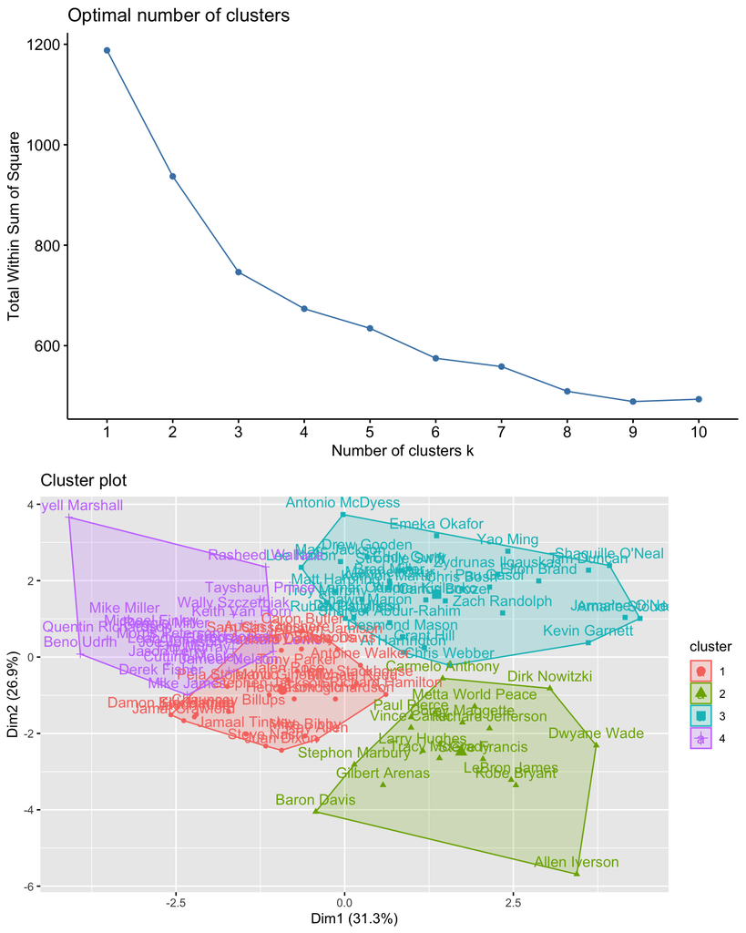

```r
stats <- df_cluster %>%
  filter(AVG_MIN>18,SEASON == 2004) %>%
  column_to_rownames('PLAYER_NAME') %>%
  select(AVG_AST,AVG_PTS,AVG_REB,AVG_STL,AVG_BLK,AVG_TO,
         AVG_FTA,AVG_2PTA,AVG_3PTA,AVG_FT_PCT,AVG_2PT_PCT,AVG_3PT_PCT) %>%
  arrange(desc(AVG_PTS)) %>%
  head(100) %>%
  scale()


elbow<-fviz_nbclust(stats, kmeans, method = "wss")


df_kmeans <- kmeans(stats,4)
cluster<-fviz_cluster(df_kmeans, stats)
grid.arrange(elbow, cluster, ncol = 1)
```

[figure not shown]

Tim Duncan e Kevin Garnett | por Brian Babineau/NBAE via Getty Images

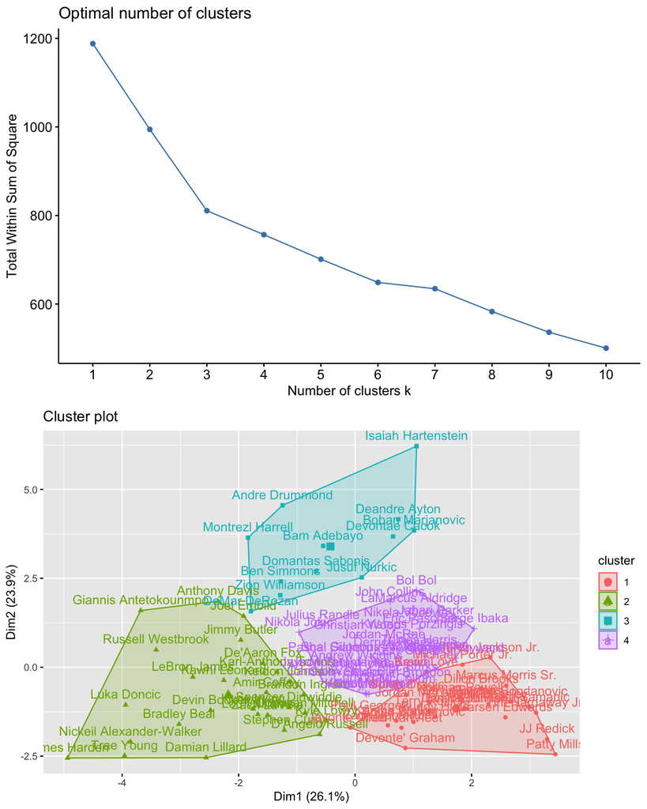

```r
stats <- df_cluster %>%
  filter(AVG_MIN>18,SEASON == 2019) %>%
  column_to_rownames('PLAYER_NAME') %>%
  select(AVG_AST,AVG_PTS,AVG_REB,AVG_STL,AVG_BLK,AVG_TO,
         AVG_FTA,AVG_2PTA,AVG_3PTA,AVG_FT_PCT,AVG_2PT_PCT,AVG_3PT_PCT) %>%
  arrange(desc(AVG_PTS)) %>%
  head(100) %>%
  scale()


elbow<-fviz_nbclust(stats, kmeans, method = "wss")


df_kmeans <- kmeans(stats,4)
cluster<-fviz_cluster(df_kmeans, stats)
grid.arrange(elbow, cluster, ncol = 1)
```

[figure not shown]

Anthony Davis e Joel Embiid | por Jonathan Daniel/Getty Images